# hw2_Le

Lin Le

3/18/2018

# Problem 1

## Section 1: Matrix Form

```r
# load data
sp <- read.csv("sprinters.csv")
```

```r
# matrix X
X <- matrix(c(rep.int(1,42), sp$year, sp$women), ncol = 3)

# matrix y
y <- matrix(sp$finish, ncol = 1)

# computing the beta
library(matrixcalc) # first, install.packages("matrixcalc")
beta <- matrix.power((t(X) %*% X), -1) %*% t(X) %*% y
```

```r
beta
```

```
##             [,1]
## [1,] 34.96003685
## [2,] -0.01260896
## [3,]  1.09281183
```

## Section 2: Fitting a linear model

### the regression

```r
library(knitr)
library(dplyr)
library(ggplot2)
library(tidyr)
```

```r
y <- sp$year
w <- sp$women
f <- sp$finish
reg1 <- lm(f ~ y + w)
summary(reg1)
```

```
##
## Call:
## lm(formula = f ~ y + w)
##
## Residuals:
##      Min       1Q   Median       3Q      Max
## -0.44623 -0.10170  0.02093  0.11094  0.45724
##
## Coefficients:
##              Estimate Std. Error t value Pr(>|t|)
## (Intercept) 34.960037   1.964903   17.79  < 2e-16 ***
## y           -0.012609   0.001005  -12.54 2.89e-15 ***
## w            1.092812   0.059502   18.37  < 2e-16 ***
## ---
## Signif. codes:  0 '***' 0.001 '**' 0.01 '*' 0.05 '.' 0.1 ' ' 1
##
## Residual standard error: 0.1852 on 39 degrees of freedom
## Multiple R-squared:  0.9125, Adjusted R-squared:  0.9081
## F-statistic: 203.5 on 2 and 39 DF,  p-value: < 2.2e-16
```

#### Comparison: the results (coefficients) are the same

### Plot 1:

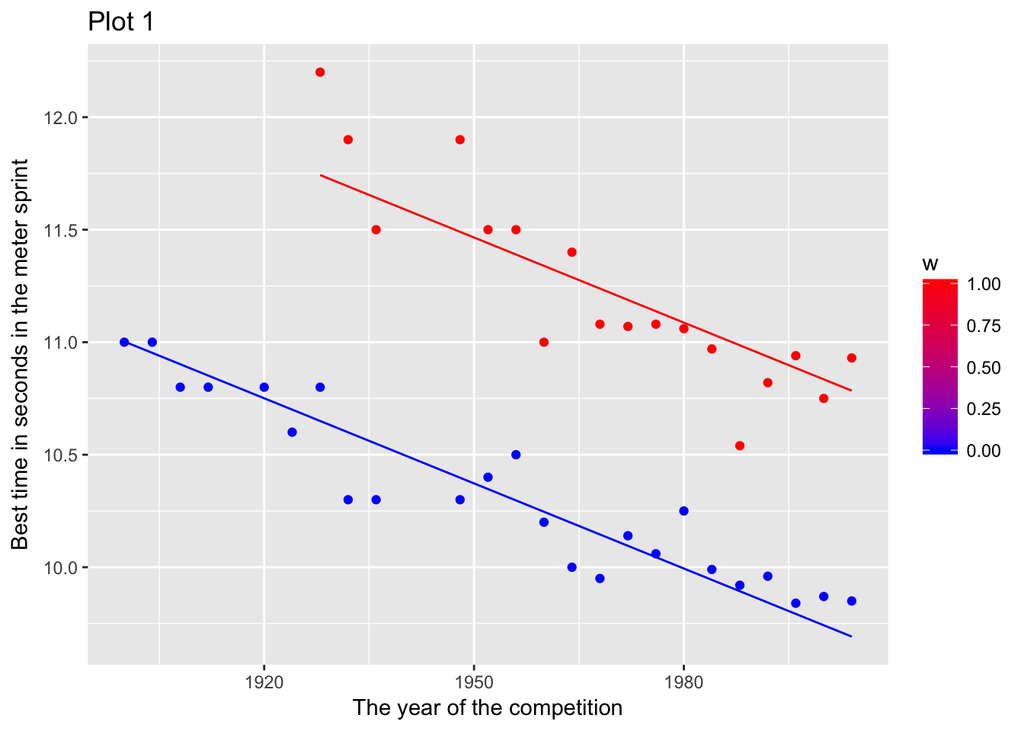

```r
p1 <- ggplot(sp %>% mutate(new = predict(reg1)),
       aes(x = y, group = w, color = w)) +
  geom_point(aes(y = f)) +
  geom_line(aes(y = new)) +
  scale_color_gradient(low="blue", high="red") +
  ylab("Best time in seconds in the meter sprint") +
  xlab("The year of the competition") +
  ggtitle("Plot 1")

p1
```

### Re-run the regression with interaction

```r
interaction <- y*w
reg2 <- lm(f ~ y + w + interaction)
summary(reg2)
```

```
##
## Call:
## lm(formula = f ~ y + w + interaction)
##
## Residuals:
##      Min       1Q   Median       3Q      Max
## -0.37579 -0.05460  0.00738  0.08276  0.32234
##
## Coefficients:
##              Estimate Std. Error t value Pr(>|t|)
## (Intercept) 31.826453   2.128910  14.950  < 2e-16 ***
## y           -0.011006   0.001089 -10.104 2.56e-12 ***
## w           12.520596   4.076141   3.072  0.00392 **
## interaction -0.005817   0.002074  -2.804  0.00791 **
## ---
## Signif. codes:  0 '***' 0.001 '**' 0.01 '*' 0.05 '.' 0.1 ' ' 1
##
## Residual standard error: 0.1707 on 38 degrees of freedom
## Multiple R-squared:  0.9275, Adjusted R-squared:  0.9218
## F-statistic: 162.1 on 3 and 38 DF,  p-value: < 2.2e-16
```

### Plot 2

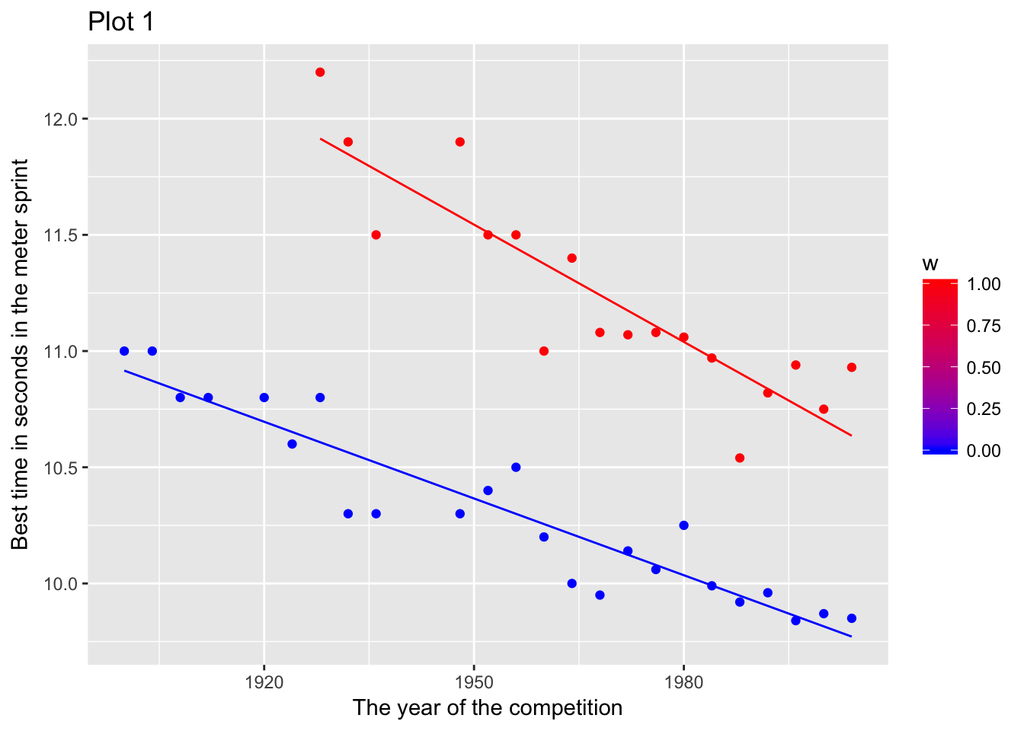

```r
p2 <- ggplot(sp %>% mutate(new = predict(reg2)),
       aes(x = y, group = w, colour = w)) +
  geom_point(aes(y = f)) +
  geom_line(aes(y = new)) +
  scale_color_gradient(low="blue", high="red") +
  ylab("Best time in seconds in the meter sprint") +
  xlab("The year of the competition") +
  ggtitle("Plot 1")

p2
```

## Section 3: Predicted Values

### using the regression model with interaction

```r
women2001 <- predict(reg2, newdata = data.frame(y = 2001, w = 1, interaction = 2001*1))
men2001 <- predict(reg2, newdata = data.frame(y = 2001, w = 0, interaction = 2001*0))
```

```r
women2001 # women
```

```
##        1
## 10.68609
```

```r
men2001 # men
```

```
##        1
## 9.804324
```

### 95% confidence interval

```r
# women
predict(reg2, newdata = data.frame(y = 2001, w = 1, interaction = 2001*1), interval = "confidence", level = 0.95)
```

```
##        fit      lwr      upr
## 1 10.68609 10.54469 10.82748
```

#### Women’s confidence interval: [10.54469, 10.82748]

```r
# men
predict(reg2, newdata = data.frame(y = 2001, w = 0, interaction = 2001*0), interval = "confidence", level = 0.95)
```

```
##        fit      lwr      upr
## 1 9.804324 9.679561 9.929086
```

#### Men’s confidence interval: [9.679561 9.929086]

### 2156 Olympics prediction

```r
women2156 <- predict(reg2, newdata = data.frame(y = 2156, w = 1, interaction = 2156*1), interval = "confidence", level = 0.95)

men2156 <- predict(reg2, newdata = data.frame(y = 2156, w = 0, interaction = 2156*0), interval = "confidence", level = 0.95)
```

```r
women2156 # women
```

```
##        fit      lwr      upr
## 1 8.078666 7.404166 8.753165
```

```r
men2156 # men
```

```
##        fit      lwr      upr
## 1 8.098462 7.648238 8.548686
```

#### Conclusin: No, I don’t trust the 2156 prediction. Relatively, I trust the 2001 prediction more than the 2156 result. The reason is that there should be a natural limit of how fast human can run.

```r
men3000 <- predict(reg2, newdata = data.frame(y = 3000, w = 0, interaction = 3000*0))
men3000
```

```
##         1
## -1.190232
```

```r
women3000 <- predict(reg2, newdata = data.frame(y = 3000, w = 1, interaction = 3000*1))
women3000
```

```
##         1
## -6.119162
```

# Problem 2

```r
data("anscombe")
library(tidyverse)
anscombe2 <- anscombe %>%
    mutate(obs = row_number()) %>%
    gather(variable_dataset, value, - obs) %>%
    separate(variable_dataset, c("variable", "dataset"), sep = 1L) %>%
    spread(variable, value) %>%
    arrange(dataset, obs)
anscombe2$dataset <- as.numeric(anscombe2$dataset)
```

## Section 4: Looking at your data beyond summary statistics

```r
x1 <-  anscombe2[anscombe2$dataset == 1,]$x
y1 <-  anscombe2[anscombe2$dataset == 1,]$y

x2 <-  anscombe2[anscombe2$dataset == 2,]$x
y2 <-  anscombe2[anscombe2$dataset == 2,]$y

x3 <-  anscombe2[anscombe2$dataset == 3,]$x
y3 <-  anscombe2[anscombe2$dataset == 3,]$y

x4 <-  anscombe2[anscombe2$dataset == 4,]$x
y4 <-  anscombe2[anscombe2$dataset == 4,]$y
```

### Dataset 1

```r
mean(x1)
```

```
## [1] 9
```

```r
mean(y1)
```

```
## [1] 7.500909
```

```r
sd(x1)
```

```
## [1] 3.316625
```

```r
sd(y1)
```

```
## [1] 2.031568
```

```r
cor(x1,y1)
```

```
## [1] 0.8164205
```

```r
# regression of dataset 1
reg1 <- lm(y1 ~ x1)
summary(reg1)
```

```
##
## Call:
## lm(formula = y1 ~ x1)
##
## Residuals:
##      Min       1Q   Median       3Q      Max
## -1.92127 -0.45577 -0.04136  0.70941  1.83882
##
## Coefficients:
##             Estimate Std. Error t value Pr(>|t|)
## (Intercept)   3.0001     1.1247   2.667  0.02573 *
## x1            0.5001     0.1179   4.241  0.00217 **
## ---
## Signif. codes:  0 '***' 0.001 '**' 0.01 '*' 0.05 '.' 0.1 ' ' 1
##
## Residual standard error: 1.237 on 9 degrees of freedom
## Multiple R-squared:  0.6665, Adjusted R-squared:  0.6295
## F-statistic: 17.99 on 1 and 9 DF,  p-value: 0.00217
```

#### Dataset 2

```r
mean(x2)
```

```
## [1] 9
```

```r
mean(y2)
```

```
## [1] 7.500909
```

```r
sd(x2)
```

```
## [1] 3.316625
```

```r
sd(y2)
```

```
## [1] 2.031657
```

```r
cor(x2,y2)
```

```
## [1] 0.8162365
```

```r
# regression of dataset 2
reg2 <- lm(y2 ~ x2)
summary(reg2)
```

```
##
## Call:
## lm(formula = y2 ~ x2)
##
## Residuals:
##     Min      1Q  Median      3Q     Max
## -1.9009 -0.7609  0.1291  0.9491  1.2691
##
## Coefficients:
##             Estimate Std. Error t value Pr(>|t|)
## (Intercept)    3.001      1.125   2.667  0.02576 *
## x2             0.500      0.118   4.239  0.00218 **
## ---
## Signif. codes:  0 '***' 0.001 '**' 0.01 '*' 0.05 '.' 0.1 ' ' 1
##
## Residual standard error: 1.237 on 9 degrees of freedom
## Multiple R-squared:  0.6662, Adjusted R-squared:  0.6292
## F-statistic: 17.97 on 1 and 9 DF,  p-value: 0.002179
```

### Dataset 3

```r
mean(x3)
```

```
## [1] 9
```

```r
mean(y3)
```

```
## [1] 7.5
```

```r
sd(x3)
```

```
## [1] 3.316625
```

```r
sd(y3)
```

```
## [1] 2.030424
```

```r
cor(x3,y3)
```

```
## [1] 0.8162867
```

```r
# regression of dataset 3
reg3 <- lm(y3 ~ x3)
summary(reg3)
```

```
##
## Call:
## lm(formula = y3 ~ x3)
##
## Residuals:
##     Min      1Q  Median      3Q     Max
## -1.1586 -0.6146 -0.2303  0.1540  3.2411
##
## Coefficients:
##             Estimate Std. Error t value Pr(>|t|)
## (Intercept)   3.0025     1.1245   2.670  0.02562 *
## x3            0.4997     0.1179   4.239  0.00218 **
## ---
## Signif. codes:  0 '***' 0.001 '**' 0.01 '*' 0.05 '.' 0.1 ' ' 1
##
## Residual standard error: 1.236 on 9 degrees of freedom
## Multiple R-squared:  0.6663, Adjusted R-squared:  0.6292
## F-statistic: 17.97 on 1 and 9 DF,  p-value: 0.002176
```

### Dataset 4

```r
mean(x4)
```

```
## [1] 9
```

```r
mean(y4)
```

```
## [1] 7.500909
```

```r
sd(x4)
```

```
## [1] 3.316625
```

```r
sd(y4)
```

```
## [1] 2.030579
```

```r
cor(x4,y4)
```

```
## [1] 0.8165214
```

```r
# regression of dataset 4
reg4 <- lm(y4 ~ x4)
summary(reg4)
```

```
##
## Call:
## lm(formula = y4 ~ x4)
##
## Residuals:
##    Min     1Q Median     3Q    Max
## -1.751 -0.831  0.000  0.809  1.839
##
## Coefficients:
##             Estimate Std. Error t value Pr(>|t|)
## (Intercept)   3.0017     1.1239   2.671  0.02559 *
## x4            0.4999     0.1178   4.243  0.00216 **
## ---
## Signif. codes:  0 '***' 0.001 '**' 0.01 '*' 0.05 '.' 0.1 ' ' 1
##
## Residual standard error: 1.236 on 9 degrees of freedom
## Multiple R-squared:  0.6667, Adjusted R-squared:  0.6297
## F-statistic:    18 on 1 and 9 DF,  p-value: 0.002165
```

#### Obervation based on regression model information: these four regression models look very similar in terms of their coefficients.

### four plots

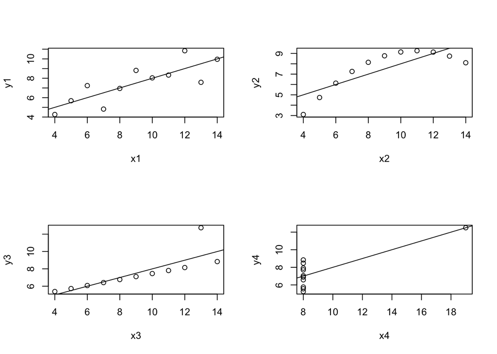

```r
par(mfrow=c(2,2))

plot(x1,y1)
abline(reg1)
plot(x2,y2)
abline(reg2)
plot(x3,y3)
abline(reg3)
plot(x4,y4)
abline(reg4)
```

#### Conclusion: data visualization is an effective way to check linearity. The four plots have almost the same regression line, but actually the regression lines produced according to the OLS rule do not necessarily capture the real picture of the data points.

# Problem 3

## Section 5: Reseaerch project

#### The key dependent variable is the number of events held in each province of China by Maoists to commemorate Mao Zedong’s birthday. So the data is continuous. (This set of number is to be normalized by the population of each province.) Higher number indicates higher degree of conservatism. The research is to explore what are the factors that explain the varying degree of conservatism in different localities in China.

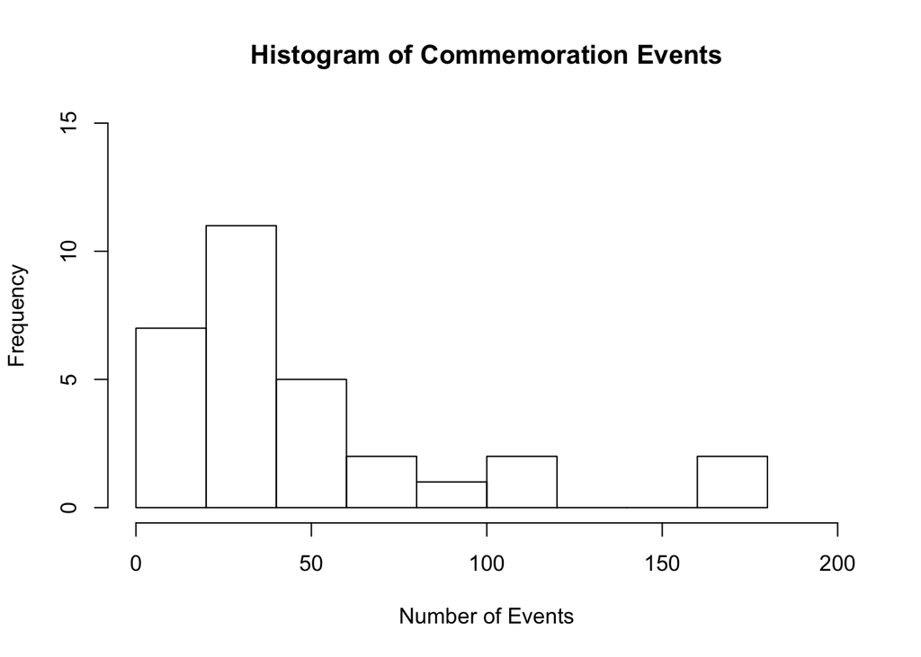

```r
eventNO <- c(171,163,119,105,94,78,72,54,50,50,48,41,39,37,32,30,28,28, 25,24,26,22,21,19,17,16,15,8,6,3)
hist(eventNO, xlim = range(0,200), ylim = range(0,15), xlab = "Number of Events", main = "Histogram of Commemoration Events")
```

#### Major independent variables include the number of designated “old revolutionary area” in each province (continuous variable), the number of death and victim during the Cultural Revolution (continuous variable), level of economic development (i.e. GDP/income/Gini Index, continuous variable), proportion of ethnic majority (continuous variable), number and scale of state-owned enterprises (continuous variable).

#### Major problems might be missing variables and multicolinearity.